# ejercicio-3-ivanir

Autor/a

Ivana Clarisa Irineo Reyes

Fecha de publicación

6 de febrero de 2026

```r
#|label: setup
#|echo: false
#|eval: false

library(knitr)
```

## Situación de investigación

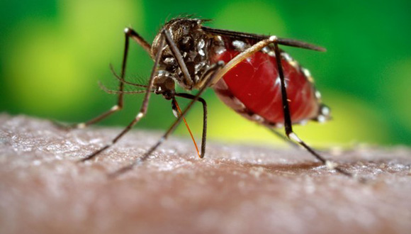

Aedes aegipty

Para ello, se toma en cuenta que las zonas de exposición a los contaminantes son: muy baja, media y alta concentración de donde se obtuvieron los mosquitos. En cada zona se atraparon 100 los cuales dieron lugar a 50 larvas de cada zona, estas larvas fueron expuestas a los siguientes tratamientos: control (nada), A: mezcla de *Bacillus thuringiensis, Bauveria bassiana, Peacelomyces fumorosae* y B: temefos.

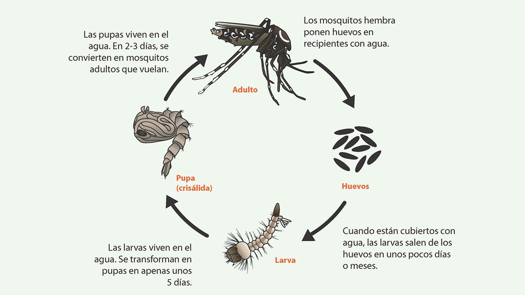

## Diseño experimental

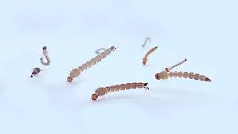

Larva de mosquito

En base a los datos presentados, se puede observar que se trata de un diseño de bloques aleatorizados donde el tipo de territorio se mantiene fijo porque se desconoce la concentración de los contaminantes de las zonas. Por lo tanto, se presentan los datos de la siguiente manera:

Una vez expuestos por 48h se midió la tasa de supervivencia. De lo cual se obtuvieron los siguientes resultados:

Supervivencia larval

| Tratamiento | Tipo de territorio | Supervivencia |
| --- | --- | --- |
| Control | pristino | 77.2 |
| Pesticida A | pristino | 58.8 |
| Pesticida B | pristino | 57.8 |
| Control | uso humano medio | 80.4 |
| Pesticida A | uso humano medio | 60.6 |
| Pesticida B | uso humano medio | 58.6 |
| Control | muy alterado | 82.3 |
| Pesticida A | muy alterado | 53.7 |
| Pesticida B | muy alterado | 46.6 |

## Arreglo de tratamientos

El modelo por bloques queda de la siguiente manera:

```
               TpTc       TpTpa        TpTpb

               TmeTc      TmeTpa       TmeTpb

               TalTc      TalTpa       TalTpb
```

Donde

Tp: Territorio prístino;

Tme: Territorio uso medio;

Tal: Territorio muy alterado

Tc: Tratamiento control;

Tpa: Tratamiento Pesticida A;

Tpb: Tratamiento Pesticida B

## Modelo correspondiente al experimento

$$y=\mu+Trat+Terr+\epsilon$$

## Supuestos de análisis estadístico

Para el desarrollo del modelo en una primera instancia supongo que los datos son normales y poseen una varianza y desviación estándar propias del tratamiento al que fueron expuestos por lo cual se analizará a través de ANOVAs y otros estadísticos correspondientes.

## Nivel de Criterio

Se tomará en cuenta que la p es de significancia cuando sea <0.05; este valor lo tomaremos en cuenta para rechazar o no la hipótesis nula.

## Exploración de datos, numérica y gráfica

```
            promedio
Control        79.97
Pesticida A    57.70
Pesticida B    54.33
```

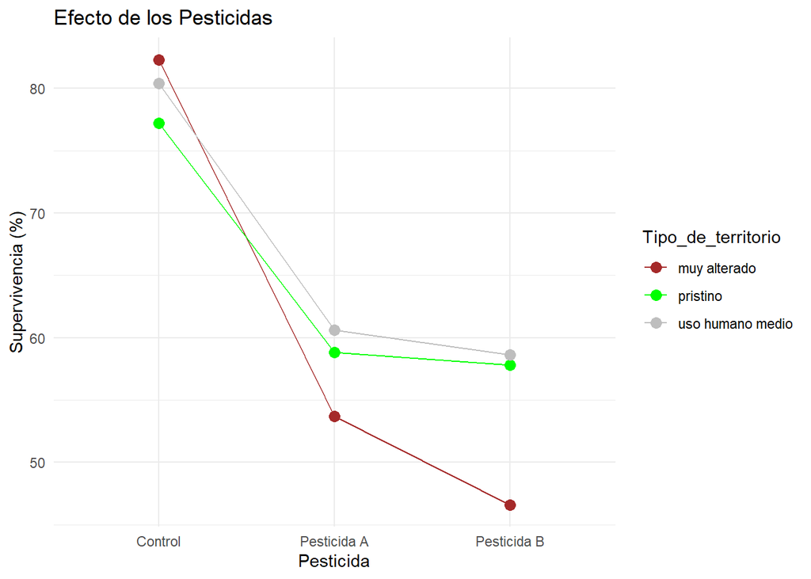

[output not shown]

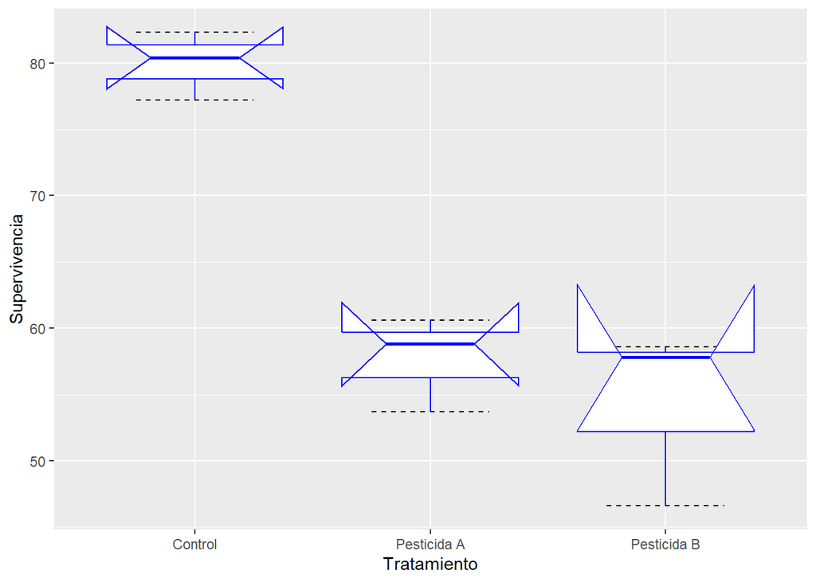

## Construye los modelos necesarios y selecciona el mínimo adecuado.

```
Call:
lm(formula = Supervivencia ~ 1, data = Supervivencia_mosquitos)

Residuals:
   Min     1Q Median     3Q    Max
 -17.4   -6.2   -5.2   13.2   18.3

Coefficients:
            Estimate Std. Error t value Pr(>|t|)
(Intercept)   64.000      4.238    15.1 3.66e-07 ***
---
Signif. codes:  0 '***' 0.001 '**' 0.01 '*' 0.05 '.' 0.1 ' ' 1

Residual standard error: 12.71 on 8 degrees of freedom
```

```
Call:
lm(formula = Supervivencia ~ Tratamiento, data = Supervivencia_mosquitos)

Residuals:
   Min     1Q Median     3Q    Max
-7.733 -2.767  1.100  2.900  4.267

Coefficients:
                       Estimate Std. Error t value Pr(>|t|)
(Intercept)              79.967      2.676  29.879 9.32e-08 ***
TratamientoPesticida A  -22.267      3.785  -5.883 0.001069 **
TratamientoPesticida B  -25.633      3.785  -6.772 0.000506 ***
---
Signif. codes:  0 '***' 0.001 '**' 0.01 '*' 0.05 '.' 0.1 ' ' 1

Residual standard error: 4.636 on 6 degrees of freedom
Multiple R-squared:  0.9003,    Adjusted R-squared:  0.8671
F-statistic: 27.09 on 2 and 6 DF,  p-value: 0.0009912
```

```
Call:
lm(formula = Supervivencia ~ Tratamiento + Tipo_de_territorio,
    data = Supervivencia_mosquitos)

Residuals:
      1       2       3       4       5       6       7       8       9
-3.3667  0.5000  2.8667 -2.1000  0.3667  1.7333  5.4667 -0.8667 -4.6000

Coefficients:
                                   Estimate Std. Error t value Pr(>|t|)
(Intercept)                          76.833      3.316  23.174 2.05e-05 ***
TratamientoPesticida A              -22.267      3.632  -6.131  0.00359 **
TratamientoPesticida B              -25.633      3.632  -7.058  0.00213 **
Tipo_de_territoriopristino            3.733      3.632   1.028  0.36208
Tipo_de_territoriouso humano medio    5.667      3.632   1.560  0.19372
---
Signif. codes:  0 '***' 0.001 '**' 0.01 '*' 0.05 '.' 0.1 ' ' 1

Residual standard error: 4.448 on 4 degrees of freedom
Multiple R-squared:  0.9388,    Adjusted R-squared:  0.8776
F-statistic: 15.34 on 4 and 4 DF,  p-value: 0.01078
```

```
Analysis of Variance Table

Model 1: Supervivencia ~ 1
Model 2: Supervivencia ~ Tratamiento
Model 3: Supervivencia ~ Tratamiento + Tipo_de_territorio
  Res.Df     RSS Df Sum of Sq       F   Pr(>F)
1      8 1293.14
2      6  128.93  2   1164.21 29.4190 0.004052 **
3      4   79.15  2     49.79  1.2581 0.376821
---
Signif. codes:  0 '***' 0.001 '**' 0.01 '*' 0.05 '.' 0.1 ' ' 1
```

El modelo mínimo adecuado sería el segundo sonde solo evaluamos la supervivencia dada el tratamiento, esto se asemeja a la formulación inicial del modelo

```
Analysis of Variance Table

Response: Supervivencia
            Df  Sum Sq Mean Sq F value    Pr(>F)
Tratamiento  2 1164.21  582.10  27.089 0.0009912 ***
Residuals    6  128.93   21.49
---
Signif. codes:  0 '***' 0.001 '**' 0.01 '*' 0.05 '.' 0.1 ' ' 1
```

## Valora la calidad del modelo, incluyendo el análisis de los residuos.

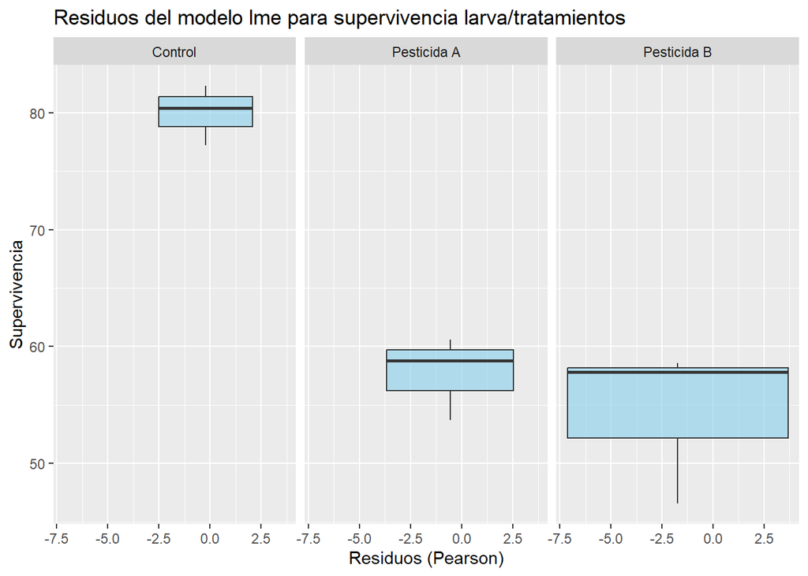

## Resuelve que tratamientos difierentes

Con base a lo observado, el tratamiento control es el que difiere con los demás, pues al observar los residuos (que concuerdan con la primer gráfica de cajas) vemos que tanto Pesticida A como Pesticida B, independientemente del lugar donde fueron obtenidas las larvas tienen un efecto en la supervivencia de las mismas, lo interesante es compara si el efecto de ambas son iguales o no; sin embargo, a través de los residuales no se observa una diferencia significativa.